# Stats

Liz Muntean

4/23/2021

One-way ANOVAs for mass

```
##              Df Sum Sq Mean Sq F value   Pr(>F)
## salttrt       1  1.502  1.5025   23.88 1.99e-06 ***
## Residuals   217 13.651  0.0629
## ---
## Signif. codes:  0 '***' 0.001 '**' 0.01 '*' 0.05 '.' 0.1 ' ' 1
## 20 observations deleted due to missingness
```

```
##              Df Sum Sq Mean Sq F value Pr(>F)
## endotrt       1  0.034 0.03429   0.492  0.484
## Residuals   217 15.119 0.06967
## 20 observations deleted due to missingness
```

One-way ANOVAs for height

```
##              Df Sum Sq Mean Sq F value  Pr(>F)
## salttrt       1   97.5    97.5    18.4 2.7e-05 ***
## Residuals   217 1149.9     5.3
## ---
## Signif. codes:  0 '***' 0.001 '**' 0.01 '*' 0.05 '.' 0.1 ' ' 1
## 20 observations deleted due to missingness
```

```
##              Df Sum Sq Mean Sq F value Pr(>F)
## endotrt       1   11.5  11.453   2.011  0.158
## Residuals   217 1235.9   5.696
## 20 observations deleted due to missingness
```

Two way ANOVAs, top is mass and bottom is height

```
##              Df Sum Sq Mean Sq F value   Pr(>F)
## salttrt       1  1.502  1.5025  23.830 2.04e-06 ***
## endotrt       1  0.033  0.0325   0.516    0.473
## Residuals   216 13.619  0.0630
## ---
## Signif. codes:  0 '***' 0.001 '**' 0.01 '*' 0.05 '.' 0.1 ' ' 1
## 20 observations deleted due to missingness
```

```
##              Df Sum Sq Mean Sq F value   Pr(>F)
## salttrt       1   97.5   97.50  18.494 2.58e-05 ***
## endotrt       1   11.2   11.19   2.124    0.147
## Residuals   216 1138.7    5.27
## ---
## Signif. codes:  0 '***' 0.001 '**' 0.01 '*' 0.05 '.' 0.1 ' ' 1
## 20 observations deleted due to missingness
```

Interaction ANOVA salt*endophyte

```
##                  Df Sum Sq Mean Sq F value  Pr(>F)
## salttrt           1  1.502  1.5025  23.778 2.1e-06 ***
## endotrt           1  0.033  0.0325   0.515   0.474
## salttrt:endotrt   1  0.033  0.0332   0.526   0.469
## Residuals       215 13.585  0.0632
## ---
## Signif. codes:  0 '***' 0.001 '**' 0.01 '*' 0.05 '.' 0.1 ' ' 1
## 20 observations deleted due to missingness
```

```
##                  Df Sum Sq Mean Sq F value   Pr(>F)
## salttrt           1   97.5   97.50  18.414 2.69e-05 ***
## endotrt           1   11.2   11.19   2.114    0.147
## salttrt:endotrt   1    0.3    0.33   0.062    0.803
## Residuals       215 1138.4    5.29
## ---
## Signif. codes:  0 '***' 0.001 '**' 0.01 '*' 0.05 '.' 0.1 ' ' 1
## 20 observations deleted due to missingness
```

Blocking ANOVA using Strain as confounding variable. Not sure if that is really appropriate here though…

```
##              Df Sum Sq Mean Sq F value   Pr(>F)
## salttrt       1  1.502  1.5025  35.041 1.35e-08 ***
## endotrt       1  0.033  0.0325   0.759    0.385
## Strain       12  4.871  0.4060   9.468 1.67e-14 ***
## Residuals   204  8.747  0.0429
## ---
## Signif. codes:  0 '***' 0.001 '**' 0.01 '*' 0.05 '.' 0.1 ' ' 1
## 20 observations deleted due to missingness
```

```
##              Df Sum Sq Mean Sq F value   Pr(>F)
## salttrt       1   97.5   97.50  30.982 8.14e-08 ***
## endotrt       1   11.2   11.19   3.557   0.0607 .
## Strain       12  496.7   41.39  13.154  < 2e-16 ***
## Residuals   204  642.0    3.15
## ---
## Signif. codes:  0 '***' 0.001 '**' 0.01 '*' 0.05 '.' 0.1 ' ' 1
## 20 observations deleted due to missingness
```

The model with the lowest AIC score (listed first in the table) is the best fit for the data. AIC weight is the percent variation in dependent variable explained by the model. More than 2 delta-AIC probably isnt a good model of explanation. So it looks like the blocking model is the best fit, individual Strains (obviously) influenced the dependent variable. Check for homoscedasticity. The diagnostic plots show the unexplained variance (residuals) across the range of the observed data. The red line representing the mean of the residuals should be horizontal and centered on zero (or on one, in the scale-location plot), meaning that there are no large outliers that would cause bias in the model.The normal Q-Q plot plots a regression between the theoretical residuals of a perfectly-heteroscedastic model and the actual residuals of your model, so the closer to a slope of 1 this is the better.

```
##
## Model selection based on AICc:
##
##                   K   AICc Delta_AICc AICcWt Cum.Wt     LL
## blocking.mass    16 -49.07       0.00      1      1  41.88
## one.way.saltmass  3  19.83      68.90      0      1  -6.86
## two.way.mass      4  21.38      70.45      0      1  -6.60
## interaction.mass  5  22.94      72.01      0      1  -6.33
## one.way.endomass  3  42.20      91.27      0      1 -18.04
```

```
##
## Model selection based on AICc:
##
##                     K    AICc Delta_AICc AICcWt Cum.Wt      LL
## blocking.height    16  891.72       0.00      1      1 -428.51
## two.way.height      4  990.72      99.00      0      1 -491.27
## one.way.saltheight  3  990.79      99.07      0      1 -492.34
## interaction.height  5  992.75     101.03      0      1 -491.23
## one.way.endoheight  3 1006.59     114.87      0      1 -500.24
```

Tukey’s Honestly Significant Difference to find which groups are statistically different from one another.

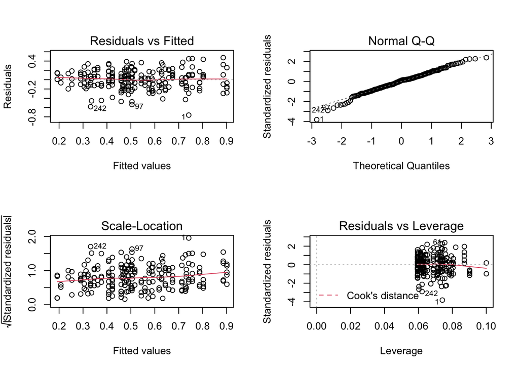

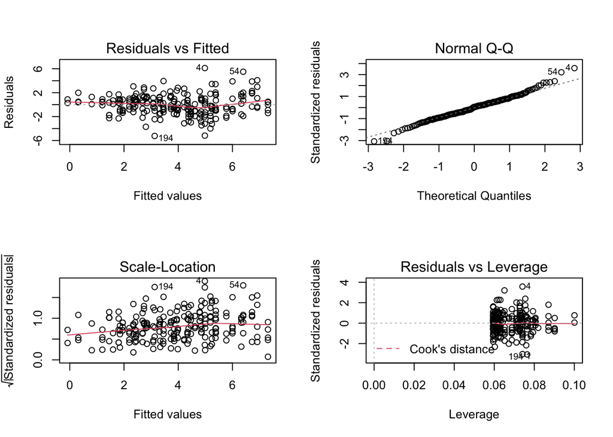

```
##   Tukey multiple comparisons of means
##     95% family-wise confidence level
##
## Fit: aov(formula = net.change.in.weight ~ salttrt + endotrt + Strain, data = bcgrowth2)
##
## $salttrt
##          diff        lwr        upr p adj
## S-F -0.167815 -0.2237102 -0.1119197     0
##
## $endotrt
##           diff         lwr        upr   p adj
## E-C 0.02438119 -0.03079618 0.07955857 0.38466
##
## $Strain
##                        diff          lwr          upr     p adj
## 10656-10630      0.19840985 -0.023989787  0.420809486 0.1344074
## 10709-10630      0.25372796  0.031328326  0.476127600 0.0107840
## 10822-10630      0.03118398 -0.201662586  0.264030538 0.9999998
## 10899-10630      0.00706188 -0.246429349  0.260553109 1.0000000
## 10899(t2)-10630  0.11700000 -0.102529844  0.336529844 0.8541065
## 10915-10630      0.42577535  0.188656017  0.662894681 0.0000006
## 10964-10630      0.28206745  0.044948121  0.519186785 0.0059961
## 10998-10630      0.32842570  0.102880226  0.553971173 0.0001556
## 1305-10630       0.04127204 -0.181127600  0.263671674 0.9999909
## 1472-10630      -0.09683374 -0.333953073  0.140285591 0.9776310
## 2039-10630      -0.05193255 -0.289051879  0.185186785 0.9999442
## 812-10630        0.16993398 -0.062912586  0.402780538 0.4159474
## 10709-10656      0.05531811 -0.169914754  0.280550981 0.9998121
## 10822-10656     -0.16722587 -0.402780044  0.068328298 0.4623122
## 10899-10656     -0.19134797 -0.447328534  0.064632594 0.3762516
## 10899(t2)-10656 -0.08140985 -0.303809486  0.140989787 0.9910768
## 10915-10656      0.22736550 -0.012413198  0.467144197 0.0821329
## 10964-10656      0.08365760 -0.156121094  0.323436301 0.9941702
## 10998-10656      0.13001585 -0.098323824  0.358355524 0.7883672
## 1305-10656      -0.15713781 -0.382370680  0.068095055 0.4915941
## 1472-10656      -0.29524359 -0.535022288 -0.055464893 0.0035485
## 2039-10656      -0.25034240 -0.490121094 -0.010563699 0.0318167
## 812-10656       -0.02847587 -0.264030044  0.207078298 0.9999999
## 10822-10709     -0.22254399 -0.458098158  0.013010184 0.0847866
## 10899-10709     -0.24666608 -0.502646647  0.009314481 0.0711604
```

[output cut: 38 more lines]

```
## 10998-10964      0.04635825 -0.196341127  0.289057621 0.9999874
## 1305-10964      -0.24079542 -0.480574113 -0.001016718 0.0479268
## 1472-10964      -0.37890119 -0.632392423 -0.125409965 0.0000868
## 2039-10964      -0.33400000 -0.587491229 -0.080508771 0.0011322
## 812-10964       -0.11213348 -0.361632468  0.137365515 0.9531706
## 1305-10998      -0.28715366 -0.515493337 -0.058813988 0.0025270
## 1472-10998      -0.42525944 -0.667958814 -0.182560066 0.0000013
## 2039-10998      -0.38035825 -0.623057621 -0.137658873 0.0000281
## 812-10998       -0.15849172 -0.397018304  0.080034858 0.5722975
## 1472-1305       -0.13810578 -0.377884476  0.101672920 0.7751974
## 2039-1305       -0.09320458 -0.332983282  0.146574113 0.9850842
## 812-1305         0.12866194 -0.106892232  0.364216110 0.8316945
## 2039-1472        0.04490119 -0.208590035  0.298392423 0.9999946
## 812-1472         0.26676772  0.017268726  0.516266709 0.0242939
## 812-2039         0.22186652 -0.027632468  0.471365515 0.1376706
```

```
##   Tukey multiple comparisons of means
##     95% family-wise confidence level
##
## Fit: aov(formula = net.change.in.height ~ salttrt + endotrt + Strain, data = bcgrowth2)
##
## $salttrt
##          diff       lwr        upr p adj
## S-F -1.351832 -1.830682 -0.8729807 1e-07
##
## $endotrt
##          diff         lwr       upr     p adj
## E-C 0.4521865 -0.02051448 0.9248874 0.0607031
##
## $Strain
##                        diff         lwr         upr     p adj
## 10656-10630      2.09719662  0.19191359  4.00247964 0.0171301
## 10709-10630      0.77900374 -1.12627929  2.68428676 0.9774143
## 10822-10630     -0.24674433 -2.24152547  1.74803682 0.9999999
## 10899-10630     -2.21269987 -4.38434251 -0.04105722 0.0413174
## 10899(t2)-10630 -0.23500000 -2.11569770  1.64569770 0.9999999
## 10915-10630      2.71977212  0.68838644  4.75115781 0.0008445
## 10964-10630      0.78991834 -1.24146734  2.82130403 0.9850372
## 10998-10630      1.79456345 -0.13766976  3.72679665 0.0979898
## 1305-10630      -0.88953005 -2.79481308  1.01575297 0.9383705
## 1472-10630      -1.45978580 -3.49117148  0.57159989 0.4418511
## 2039-10630      -2.73674832 -4.76813401 -0.70536264 0.0007518
## 812-10630        0.65325567 -1.34152547  2.64803682 0.9967372
## 10709-10656     -1.31819288 -3.24774800  0.61136225 0.5267136
## 10822-10656     -2.34394094 -4.36191800 -0.32596389 0.0084343
## 10899-10656     -4.30989648 -6.50286510 -2.11692786 0.0000000
## 10899(t2)-10656 -2.33219662 -4.23747964 -0.42691359 0.0038921
## 10915-10656      0.62257551 -1.43159279  2.67674380 0.9984368
## 10964-10656     -1.30727827 -3.36144657  0.74689002 0.6401637
## 10998-10656     -0.30263317 -2.25880411  1.65353777 0.9999988
## 1305-10656      -2.98672667 -4.91628180 -1.05717154 0.0000381
## 1472-10656      -3.55698241 -5.61115071 -1.50281412 0.0000019
## 2039-10656      -4.83394494 -6.88811323 -2.77977664 0.0000000
## 812-10656       -1.44394094 -3.46191800  0.57403611 0.4490632
## 10822-10709     -1.02574807 -3.04372512  0.99222899 0.8909364
## 10899-10709     -2.99170360 -5.18467222 -0.79873499 0.0005922
```

[output cut: 38 more lines]

```
## 10998-10964      1.00464510 -1.07454444  3.08383464 0.9218211
## 1305-10964      -1.67944840 -3.73361669  0.37471990 0.2391066
## 1472-10964      -2.24970414 -4.42134679 -0.07806150 0.0346460
## 2039-10964      -3.52666667 -5.69830931 -1.35502402 0.0000113
## 812-10964       -0.13666267 -2.27410408  2.00077874 1.0000000
## 1305-10998      -2.68409350 -4.64026444 -0.72792256 0.0005296
## 1472-10998      -3.25434924 -5.33353878 -1.17515971 0.0000290
## 2039-10998      -4.53131177 -6.61050131 -2.45212223 0.0000000
## 812-10998       -1.14130777 -3.18474927  0.90213372 0.8093130
## 1472-1305       -0.57025574 -2.62442404  1.48391255 0.9993418
## 2039-1305       -1.84721827 -3.90138656  0.20695003 0.1266047
## 812-1305         1.54278572 -0.47519133  3.56076278 0.3398066
## 2039-1472       -1.27696252 -3.44860517  0.89468012 0.7501556
## 812-1472         2.11304147 -0.02439994  4.25048288 0.0559677
## 812-2039         3.39000399  1.25256258  5.52744541 0.0000208
```

Groupwise comparisons Salt:Endo for mass (top) and height (bottom).

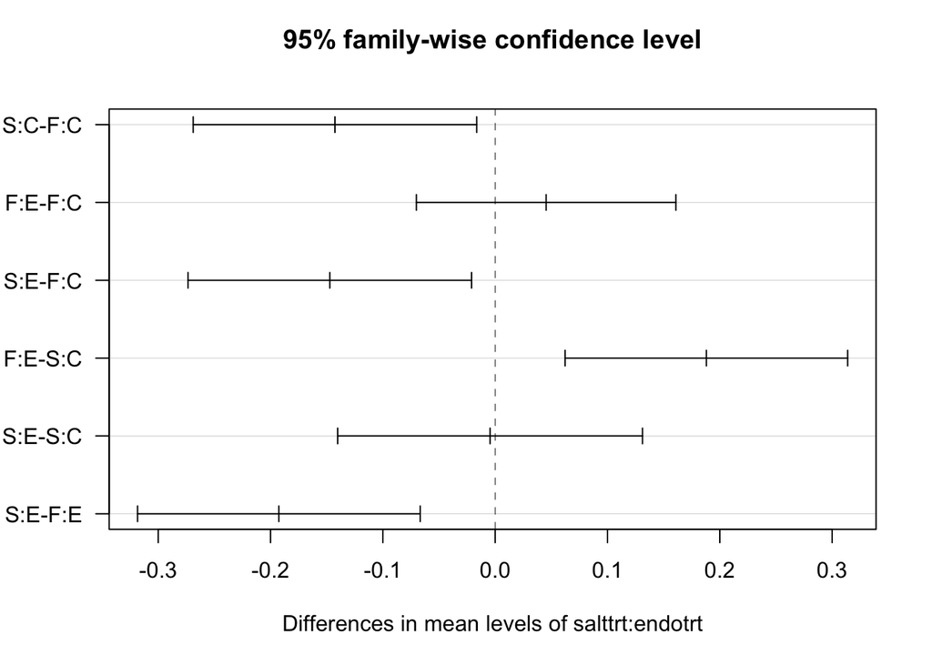

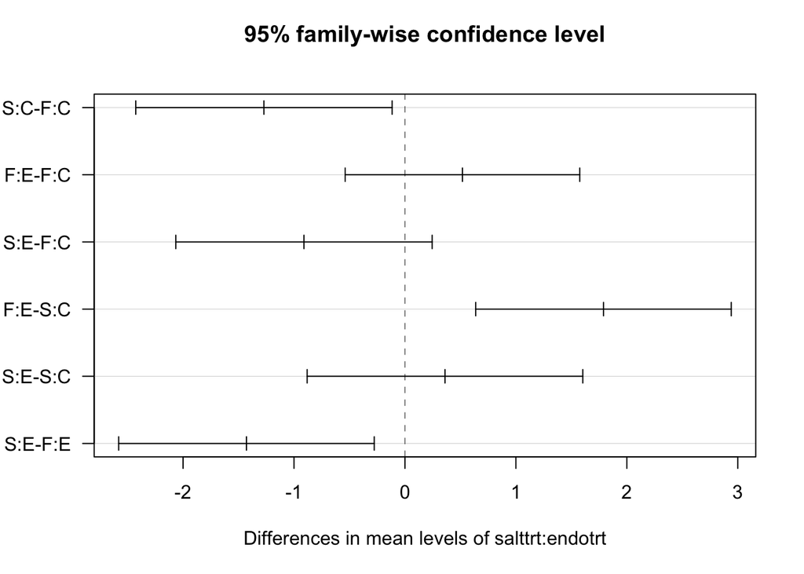

```
## # A tibble: 4 x 3
## # Groups:   salttrt [2]
##   salttrt endotrt  mass
##   <chr>   <chr>   <dbl>
## 1 F       C       0.577
## 2 F       E       0.623
## 3 S       C       0.435
## 4 S       E       0.430
```

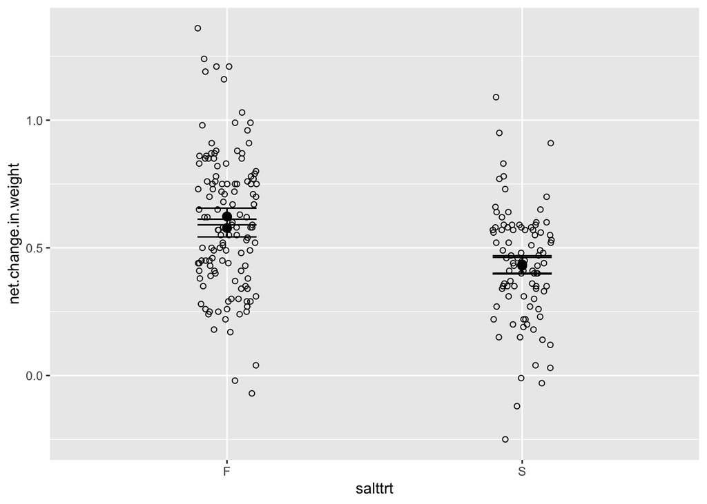

```
##             Df Sum Sq Mean Sq F value Pr(>F)
## salttrt      1 0.2778 0.27778   6.024 0.0259 *
## Residuals   16 0.7378 0.04611
## ---
## Signif. codes:  0 '***' 0.001 '**' 0.01 '*' 0.05 '.' 0.1 ' ' 1
```

```
##             Df Sum Sq Mean Sq F value Pr(>F)
## endotrt      1 0.1436  0.1436   2.635  0.124
## Residuals   16 0.8720  0.0545
```

```
##             Df Sum Sq Mean Sq F value Pr(>F)
## salttrt      1 0.2778 0.27778   6.528  0.022 *
## endotrt      1 0.0996 0.09957   2.340  0.147
## Residuals   15 0.6382 0.04255
## ---
## Signif. codes:  0 '***' 0.001 '**' 0.01 '*' 0.05 '.' 0.1 ' ' 1
```

```
##                 Df Sum Sq Mean Sq F value Pr(>F)
## salttrt          1 0.2778 0.27778   6.526 0.0229 *
## endotrt          1 0.0996 0.09957   2.339 0.1484
## salttrt:endotrt  1 0.0423 0.04229   0.993 0.3358
## Residuals       14 0.5959 0.04257
## ---
## Signif. codes:  0 '***' 0.001 '**' 0.01 '*' 0.05 '.' 0.1 ' ' 1
```

```
##
## Model selection based on AICc:
##
##                        K AICc Delta_AICc AICcWt Cum.Wt   LL
## one.way.salt.10998     3 1.30       0.00   0.48   0.48 3.21
## two.way.mass.10998     4 2.05       0.75   0.33   0.81 4.51
## one.way.endo.10998     3 4.30       3.01   0.11   0.91 1.71
## interaction.mass.10998 5 4.74       3.44   0.09   1.00 5.13
```

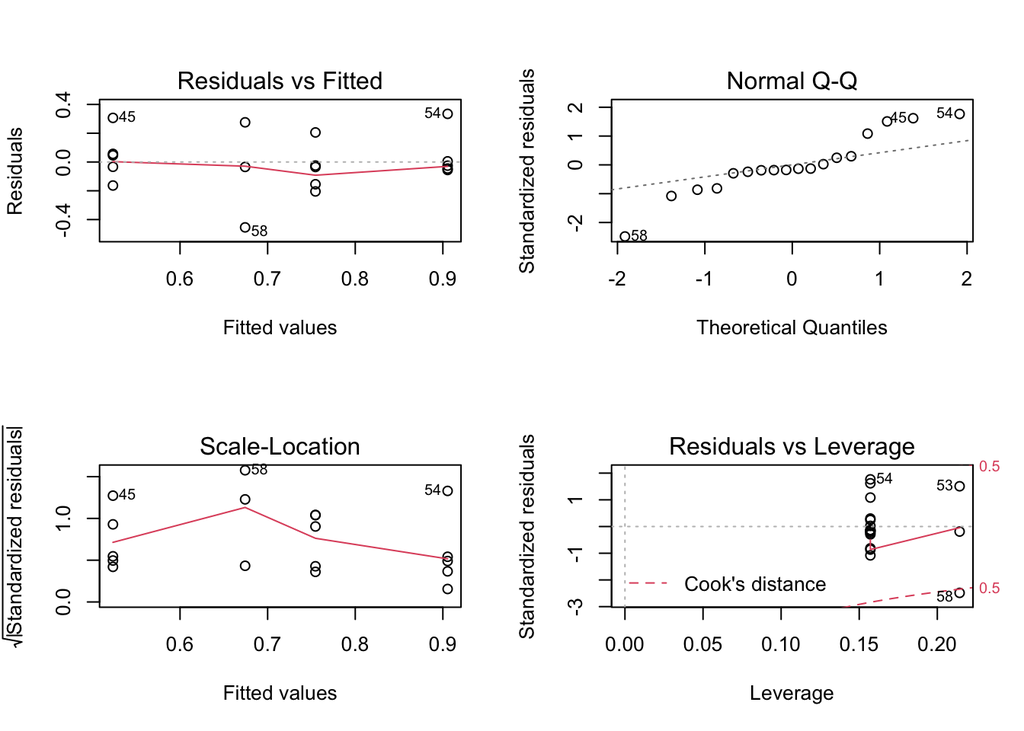

```
##   Tukey multiple comparisons of means
##     95% family-wise confidence level
##
## Fit: aov(formula = net.change.in.weight ~ salttrt + endotrt, data = df10998)
##
## $salttrt
##      diff        lwr         upr     p adj
## S-F -0.25 -0.4585503 -0.04144974 0.0219755
##
## $endotrt
##       diff         lwr       upr     p adj
## E-C 0.1485 -0.06005026 0.3570503 0.1498776
```

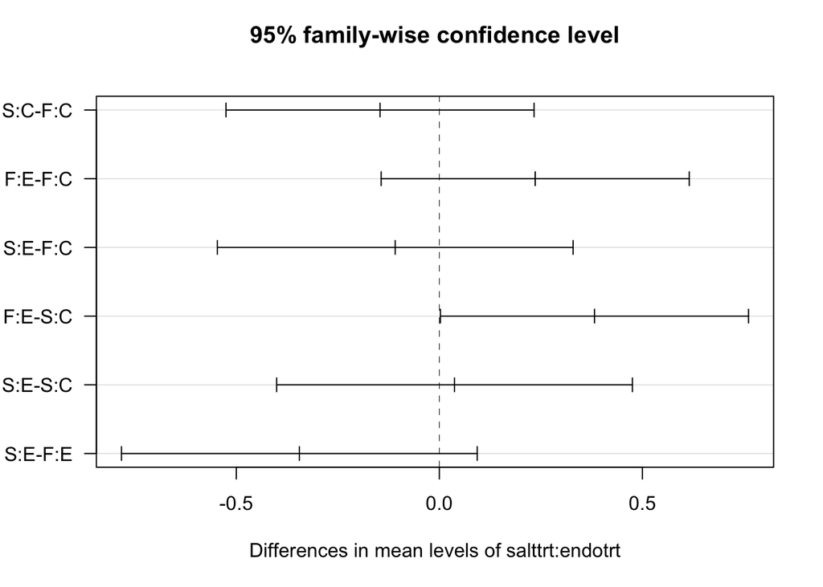

```
## # A tibble: 4 x 3
## # Groups:   salttrt [2]
##   salttrt endotrt  mass
##   <chr>   <chr>   <dbl>
## 1 F       C       0.712
## 2 F       E       0.948
## 3 S       C       0.566
## 4 S       E       0.603
```

[output not shown]

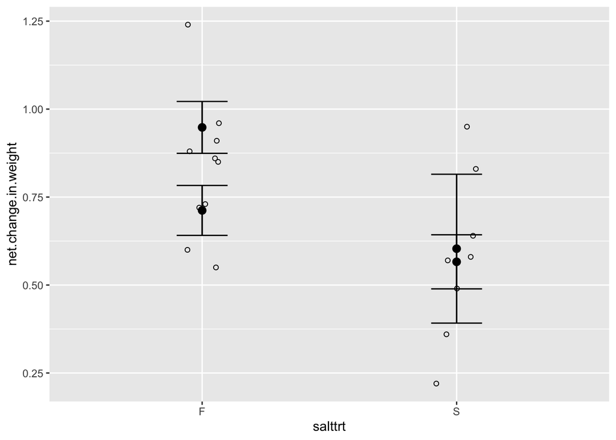